# Homework 4

Toygar Emre

29 01 2021

1. FIRST PROBLEM: REGRESSION

Data is taken from here: https://archive.ics.uci.edu/ml/datasets/communities+and+crime

Source:

Creator: Michael Redmond (redmond ‘at’ lasalle.edu); Computer Science; La Salle University; Philadelphia, PA, 19141, USA – culled from 1990 US Census, 1995 US FBI Uniform Crime Report, 1990 US Law Enforcement Management and Administrative Statistics Survey, available from ICPSR at U of Michigan. – Donor: Michael Redmond (redmond ‘at’ lasalle.edu); Computer Science; La Salle University; Philadelphia, PA, 19141, USA – Date: July 2009

Data Set Information:

Many variables are included so that algorithms that select or learn weights for attributes could be tested. However, clearly unrelated attributes were not included; attributes were picked if there was any plausible connection to crime (N=122), plus the attribute to be predicted (Per Capita Violent Crimes). The variables included in the dataset involve the community, such as the percent of the population considered urban, and the median family income, and involving law enforcement, such as per capita number of police officers, and percent of officers assigned to drug units.

The per capita violent crimes variable was calculated using population and the sum of crime variables considered violent crimes in the United States: murder, rape, robbery, and assault. There was apparently some controversy in some states concerning the counting of rapes. These resulted in missing values for rape, which resulted in incorrect values for per capita violent crime. These cities are not included in the dataset. Many of these omitted communities were from the midwestern USA.

Data is described below based on original values. All numeric data was normalized into the decimal range 0.00-1.00 using an Unsupervised, equal-interval binning method. Attributes retain their distribution and skew (hence for example the population attribute has a mean value of 0.06 because most communities are small). E.g. An attribute described as ‘mean people per household’ is actually the normalized (0-1) version of that value.

The normalization preserves rough ratios of values WITHIN an attribute (e.g. double the value for double the population within the available precision - except for extreme values (all values more than 3 SD above the mean are normalized to 1.00; all values more than 3 SD below the mean are nromalized to 0.00)).

However, the normalization does not preserve relationships between values BETWEEN attributes (e.g. it would not be meaningful to compare the value for whitePerCap with the value for blackPerCap for a community)

A limitation was that the LEMAS survey was of the police departments with at least 100 officers, plus a random sample of smaller departments. For our purposes, communities not found in both census and crime datasets were omitted. Many communities are missing LEMAS data.

We will not make any transformation or manipulation known as feature engineering other than necessary ones such as deleting non predictive columns or filling NA values.

```r
library(caret)
library(tidyverse)
library(doSNOW)
library(mlr)
```

```r
library(rpart)
library(rpart.plot)
library(randomForest)
library(gbm)
```

Data consists of 1994 instances and 123 features and there are missing values as can be seen

Summary of data

```r
communities_raw=tibble(read.table("communities.data",sep=","))
dim(communities_raw)
```

```
## [1] 1994  128
```

```r
summary(communities_raw)
```

```
##        V1              V2               V3             V4
##  Min.   : 1.00   Min.   :  1.00   Min.   :   70   Length:1994
##  1st Qu.:12.00   1st Qu.:  9.00   1st Qu.:25065   Class :character
##  Median :34.00   Median : 23.00   Median :48090   Mode  :character
##  Mean   :28.68   Mean   : 58.83   Mean   :46188
##  3rd Qu.:42.00   3rd Qu.: 59.50   3rd Qu.:66660
##  Max.   :56.00   Max.   :840.00   Max.   :94597
##                  NA's   :1174     NA's   :1177
##        V5               V6                V7               V8
##  Min.   : 1.000   Min.   :0.00000   Min.   :0.0000   Min.   :0.0000
##  1st Qu.: 3.000   1st Qu.:0.01000   1st Qu.:0.3500   1st Qu.:0.0200
##  Median : 5.000   Median :0.02000   Median :0.4400   Median :0.0600
##  Mean   : 5.494   Mean   :0.05759   Mean   :0.4634   Mean   :0.1796
##  3rd Qu.: 8.000   3rd Qu.:0.05000   3rd Qu.:0.5400   3rd Qu.:0.2300
##  Max.   :10.000   Max.   :1.00000   Max.   :1.0000   Max.   :1.0000
##
##        V9              V10              V11             V12
##  Min.   :0.0000   Min.   :0.0000   Min.   :0.000   Min.   :0.0000
##  1st Qu.:0.6300   1st Qu.:0.0400   1st Qu.:0.010   1st Qu.:0.3400
##  Median :0.8500   Median :0.0700   Median :0.040   Median :0.4000
##  Mean   :0.7537   Mean   :0.1537   Mean   :0.144   Mean   :0.4242
##  3rd Qu.:0.9400   3rd Qu.:0.1700   3rd Qu.:0.160   3rd Qu.:0.4700
##  Max.   :1.0000   Max.   :1.0000   Max.   :1.000   Max.   :1.0000
##
##       V13              V14              V15              V16
##  Min.   :0.0000   Min.   :0.0000   Min.   :0.0000   Min.   :0.00000
##  1st Qu.:0.4100   1st Qu.:0.2500   1st Qu.:0.3000   1st Qu.:0.00000
##  Median :0.4800   Median :0.2900   Median :0.4200   Median :0.03000
##  Mean   :0.4939   Mean   :0.3363   Mean   :0.4232   Mean   :0.06407
##  3rd Qu.:0.5400   3rd Qu.:0.3600   3rd Qu.:0.5300   3rd Qu.:0.07000
##  Max.   :1.0000   Max.   :1.0000   Max.   :1.0000   Max.   :1.00000
##
##       V17              V18              V19              V20
##  Min.   :0.0000   Min.   :0.0000   Min.   :0.0000   Min.   :0.0000
##  1st Qu.:0.0000   1st Qu.:0.2000   1st Qu.:0.4400   1st Qu.:0.1600
##  Median :1.0000   Median :0.3200   Median :0.5600   Median :0.2300
##  Mean   :0.6963   Mean   :0.3611   Mean   :0.5582   Mean   :0.2916
##  3rd Qu.:1.0000   3rd Qu.:0.4900   3rd Qu.:0.6900   3rd Qu.:0.3700
##  Max.   :1.0000   Max.   :1.0000   Max.   :1.0000   Max.   :1.0000
##
```

[output cut: 201 more lines]

```
##  Min.   :0.0000   Min.   :0.0000   Min.   :0.0000   Min.   :0.0000
##  1st Qu.:0.0200   1st Qu.:0.0400   1st Qu.:0.0200   1st Qu.:0.6200
##  Median :0.0700   Median :0.0800   Median :0.0300   Median :0.7500
##  Mean   :0.1617   Mean   :0.1631   Mean   :0.0767   Mean   :0.6986
##  3rd Qu.:0.1900   3rd Qu.:0.1950   3rd Qu.:0.0600   3rd Qu.:0.8400
##  Max.   :1.0000   Max.   :1.0000   Max.   :1.0000   Max.   :1.0000
##                   NA's   :1675     NA's   :1675     NA's   :1675
##       V125             V126              V127             V128
##  Min.   :0.0000   Min.   :0.00000   Min.   :0.0000   Min.   :0.000
##  1st Qu.:0.0000   1st Qu.:0.00000   1st Qu.:0.1100   1st Qu.:0.070
##  Median :0.5000   Median :0.00000   Median :0.1500   Median :0.150
##  Mean   :0.4404   Mean   :0.09405   Mean   :0.1951   Mean   :0.238
##  3rd Qu.:1.0000   3rd Qu.:0.00000   3rd Qu.:0.2200   3rd Qu.:0.330
##  Max.   :1.0000   Max.   :1.00000   Max.   :1.0000   Max.   :1.000
##  NA's   :1675                       NA's   :1675
```

```r
str(communities_raw)
```

```
## tibble [1,994 x 128] (S3: tbl_df/tbl/data.frame)
##  $ V1  : int [1:1994] 8 53 24 34 42 6 44 6 21 29 ...
##  $ V2  : int [1:1994] NA NA NA 5 95 NA 7 NA NA NA ...
##  $ V3  : int [1:1994] NA NA NA 81440 6096 NA 41500 NA NA NA ...
##  $ V4  : chr [1:1994] "Lakewoodcity" "Tukwilacity" "Aberdeentown" "Willingborotownship" ...
##  $ V5  : int [1:1994] 1 1 1 1 1 1 1 1 1 1 ...
##  $ V6  : num [1:1994] 0.19 0 0 0.04 0.01 0.02 0.01 0.01 0.03 0.01 ...
##  $ V7  : num [1:1994] 0.33 0.16 0.42 0.77 0.55 0.28 0.39 0.74 0.34 0.4 ...
##  $ V8  : num [1:1994] 0.02 0.12 0.49 1 0.02 0.06 0 0.03 0.2 0.06 ...
##  $ V9  : num [1:1994] 0.9 0.74 0.56 0.08 0.95 0.54 0.98 0.46 0.84 0.87 ...
##  $ V10 : num [1:1994] 0.12 0.45 0.17 0.12 0.09 1 0.06 0.2 0.02 0.3 ...
##  $ V11 : num [1:1994] 0.17 0.07 0.04 0.1 0.05 0.25 0.02 1 0 0.03 ...
##  $ V12 : num [1:1994] 0.34 0.26 0.39 0.51 0.38 0.31 0.3 0.52 0.38 0.9 ...
##  $ V13 : num [1:1994] 0.47 0.59 0.47 0.5 0.38 0.48 0.37 0.55 0.45 0.82 ...
##  $ V14 : num [1:1994] 0.29 0.35 0.28 0.34 0.23 0.27 0.23 0.36 0.28 0.8 ...
```

[output cut: 86 more lines]

```r
comm<-communities_raw %>%
  select(-c(1:5)) %>% # These are non predictives so we remove them
  rename(Y=V128) # Our goal to predict which is violent crimes per population

# Filling NA values with median of each column
preproc<-preProcess(comm,method = "medianImpute")
comm<-predict(preproc,comm)
# 30% of data is selected for test
set.seed(123)
TrainIndex <- sample(1:nrow(comm),size = trunc(nrow(comm)*0.7),replace = F)

train_comm<- comm[TrainIndex,] %>% as.data.frame()
test_comm <- comm[-TrainIndex,] %>% as.data.frame()

Traindat<-train_comm %>% select(-Y)
TrainResponse<-train_comm$Y


control.param<-trainControl(method = "cv",
                            number = 10,
                            allowParallel = F,
                            returnResamp = "all",
                            savePredictions = "all")
```

RMSE will be used as performance metric for this question. It is commonly used in regression problems

1. Glmnet Method

```r
# Meaningful lambda values are selected for cross validation
Grid.Matrix= expand.grid(alpha=1,
                         lambda=c(0.0001,0.001,0.005,0.01,0.05,0.1))

set.seed(123)
fit.glmnet <- caret::train(x = Traindat ,
                           y = TrainResponse,
                           method = "glmnet",
                           trControl = control.param,
                           tuneGrid = Grid.Matrix,
                           metric="RMSE")
print(fit.glmnet)
```

```
## glmnet
##
## 1395 samples
##  122 predictor
##
## No pre-processing
## Resampling: Cross-Validated (10 fold)
## Summary of sample sizes: 1254, 1256, 1256, 1255, 1257, 1256, ...
## Resampling results across tuning parameters:
##
##   lambda  RMSE       Rsquared   MAE
##   1e-04   0.1398611  0.6264945  0.09852299
##   1e-03   0.1389039  0.6306263  0.09699596
##   5e-03   0.1388133  0.6316796  0.09649497
##   1e-02   0.1398324  0.6289346  0.09728922
##   5e-02   0.1567145  0.5860020  0.11361109
##   1e-01   0.1833256  0.5598323  0.13843734
##
## Tuning parameter 'alpha' was held constant at a value of 1
## RMSE was used to select the optimal model using the smallest value.
## The final values used for the model were alpha = 1 and lambda = 0.005.
```

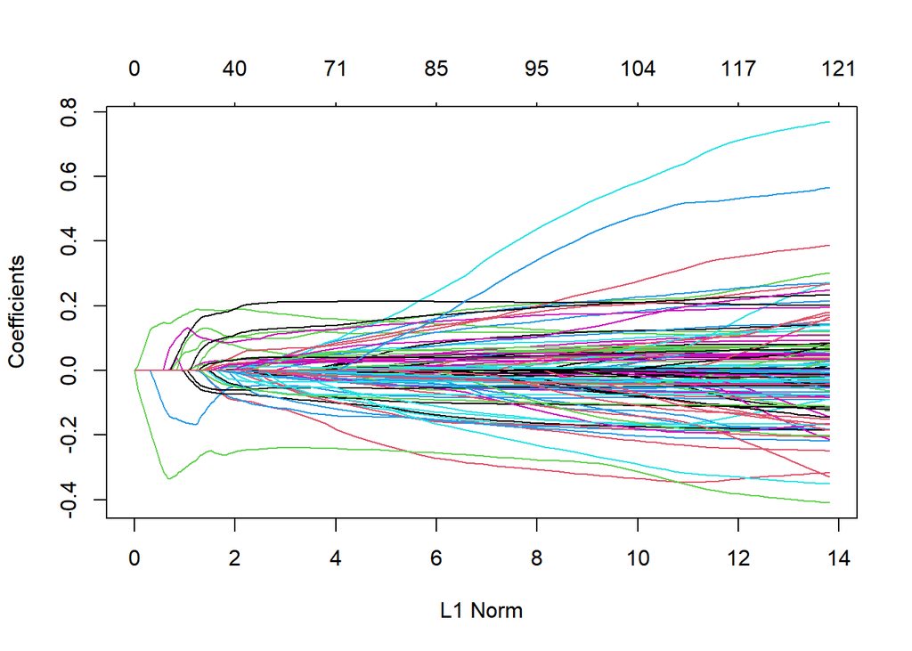

```r
plot(fit.glmnet$finalModel)
```

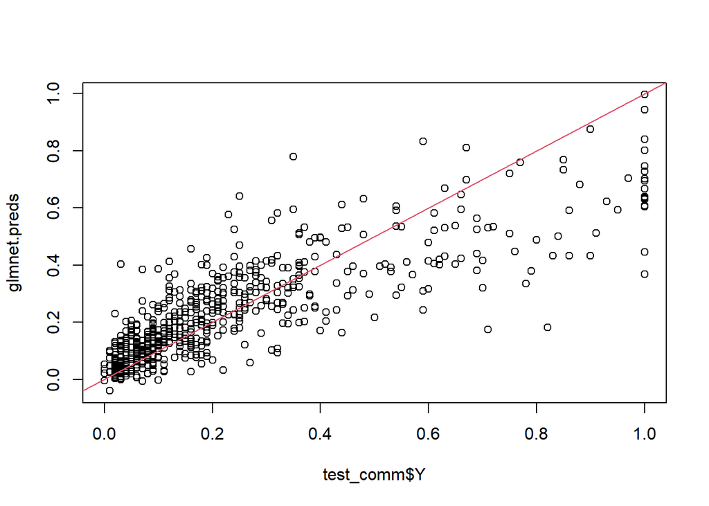

```r
glmnet.preds=predict(fit.glmnet,test_comm)
plot(test_comm$Y,glmnet.preds)
abline(a=0,b=1,col=2)
```

```r
glmnet.perf<-RMSE(pred = glmnet.preds,obs = test_comm$Y)
print(glmnet.perf)
```

```
## [1] 0.1361839
```

2. Rpart Method

```r
# Since in caret package we do not have minsplit parameter to tune for we will use mlr package for rpart method for all questions.
regr.task = makeRegrTask(id = "comm", data = train_comm, target = "Y")
resamp = makeResampleDesc("CV", iters = 10)
lrn = makeLearner("regr.rpart")
control.grid = makeTuneControlGrid()
ps = makeParamSet(
  makeDiscreteParam("cp", values = c(0.001,0.005,0.01,0.02,0.05,0.1)),
  makeDiscreteParam("minsplit", values = seq(1,11,length.out = 6))
)

set.seed(123)
fit.rpart = tuneParams(lrn, task = regr.task, resampling = resamp, control = control.grid, par.set = ps, measures = list(rmse,timetrain))
```

```
## [Tune] Started tuning learner regr.rpart for parameter set:
```

```
##              Type len Def                         Constr Req Tunable Trafo
## cp       discrete   -   - 0.001,0.005,0.01,0.02,0.05,0.1   -    TRUE     -
## minsplit discrete   -   -                   1,3,5,7,9,11   -    TRUE     -
```

```
## With control class: TuneControlGrid
```

```
## Imputation value: InfImputation value: Inf
```

```
## [Tune-x] 1: cp=0.001; minsplit=1
```

```
## [Tune-y] 1: rmse.test.rmse=0.2297733,timetrain.test.mean=0.0220000; time: 0.0 min
```

```
## [Tune-x] 2: cp=0.005; minsplit=1
```

```
## [Tune-y] 2: rmse.test.rmse=0.2256877,timetrain.test.mean=0.0230000; time: 0.0 min
```

```
## [Tune-x] 3: cp=0.01; minsplit=1
```

```
## [Tune-y] 3: rmse.test.rmse=0.2297733,timetrain.test.mean=0.0270000; time: 0.0 min
```

```
## [Tune-x] 4: cp=0.02; minsplit=1
```

```
## [Tune-y] 4: rmse.test.rmse=0.2256877,timetrain.test.mean=0.0240000; time: 0.0 min
```

```
## [Tune-x] 5: cp=0.05; minsplit=1
```

```
## [Tune-y] 5: rmse.test.rmse=0.2297733,timetrain.test.mean=0.0430000; time: 0.0 min
```

```
## [Tune-x] 6: cp=0.1; minsplit=1
```

```
## [Tune-y] 6: rmse.test.rmse=0.2297733,timetrain.test.mean=0.0210000; time: 0.0 min
```

```
## [Tune-x] 7: cp=0.001; minsplit=3
```

```
## [Tune-y] 7: rmse.test.rmse=0.2001800,timetrain.test.mean=0.0610000; time: 0.0 min
```

```
## [Tune-x] 8: cp=0.005; minsplit=3
```

```
## [Tune-y] 8: rmse.test.rmse=0.1765850,timetrain.test.mean=0.0460000; time: 0.0 min
```

```
## [Tune-x] 9: cp=0.01; minsplit=3
```

```
## [Tune-y] 9: rmse.test.rmse=0.1650555,timetrain.test.mean=0.0400000; time: 0.0 min
```

```
## [Tune-x] 10: cp=0.02; minsplit=3
```

```
## [Tune-y] 10: rmse.test.rmse=0.1668538,timetrain.test.mean=0.0380000; time: 0.0 min
```

```
## [Tune-x] 11: cp=0.05; minsplit=3
```

```
## [Tune-y] 11: rmse.test.rmse=0.1719848,timetrain.test.mean=0.0340000; time: 0.0 min
```

```
## [Tune-x] 12: cp=0.1; minsplit=3
```

```
## [Tune-y] 12: rmse.test.rmse=0.1844607,timetrain.test.mean=0.0340000; time: 0.0 min
```

```
## [Tune-x] 13: cp=0.001; minsplit=5
```

```
## [Tune-y] 13: rmse.test.rmse=0.1938698,timetrain.test.mean=0.0530000; time: 0.0 min
```

```
## [Tune-x] 14: cp=0.005; minsplit=5
```

```
## [Tune-y] 14: rmse.test.rmse=0.1730416,timetrain.test.mean=0.0440000; time: 0.0 min
```

```
## [Tune-x] 15: cp=0.01; minsplit=5
```

```
## [Tune-y] 15: rmse.test.rmse=0.1650510,timetrain.test.mean=0.0410000; time: 0.0 min
```

```
## [Tune-x] 16: cp=0.02; minsplit=5
```

```
## [Tune-y] 16: rmse.test.rmse=0.1668538,timetrain.test.mean=0.0380000; time: 0.0 min
```

```
## [Tune-x] 17: cp=0.05; minsplit=5
```

```
## [Tune-y] 17: rmse.test.rmse=0.1719848,timetrain.test.mean=0.0310000; time: 0.0 min
```

```
## [Tune-x] 18: cp=0.1; minsplit=5
```

```
## [Tune-y] 18: rmse.test.rmse=0.1844607,timetrain.test.mean=0.0290000; time: 0.0 min
```

```
## [Tune-x] 19: cp=0.001; minsplit=7
```

```
## [Tune-y] 19: rmse.test.rmse=0.1926387,timetrain.test.mean=0.0630000; time: 0.0 min
```

```
## [Tune-x] 20: cp=0.005; minsplit=7
```

```
## [Tune-y] 20: rmse.test.rmse=0.1730416,timetrain.test.mean=0.0470000; time: 0.0 min
```

```
## [Tune-x] 21: cp=0.01; minsplit=7
```

```
## [Tune-y] 21: rmse.test.rmse=0.1650510,timetrain.test.mean=0.0420000; time: 0.0 min
```

```
## [Tune-x] 22: cp=0.02; minsplit=7
```

```
## [Tune-y] 22: rmse.test.rmse=0.1668538,timetrain.test.mean=0.0620000; time: 0.0 min
```

```
## [Tune-x] 23: cp=0.05; minsplit=7
```

```
## [Tune-y] 23: rmse.test.rmse=0.1719848,timetrain.test.mean=0.0330000; time: 0.0 min
```

```
## [Tune-x] 24: cp=0.1; minsplit=7
```

```
## [Tune-y] 24: rmse.test.rmse=0.1844607,timetrain.test.mean=0.0330000; time: 0.0 min
```

```
## [Tune-x] 25: cp=0.001; minsplit=9
```

```
## [Tune-y] 25: rmse.test.rmse=0.1840038,timetrain.test.mean=0.0540000; time: 0.0 min
```

```
## [Tune-x] 26: cp=0.005; minsplit=9
```

```
## [Tune-y] 26: rmse.test.rmse=0.1713745,timetrain.test.mean=0.0450000; time: 0.0 min
```

```
## [Tune-x] 27: cp=0.01; minsplit=9
```

```
## [Tune-y] 27: rmse.test.rmse=0.1647113,timetrain.test.mean=0.0440000; time: 0.0 min
```

```
## [Tune-x] 28: cp=0.02; minsplit=9
```

```
## [Tune-y] 28: rmse.test.rmse=0.1668538,timetrain.test.mean=0.0390000; time: 0.0 min
```

```
## [Tune-x] 29: cp=0.05; minsplit=9
```

```
## [Tune-y] 29: rmse.test.rmse=0.1719848,timetrain.test.mean=0.0360000; time: 0.0 min
```

```
## [Tune-x] 30: cp=0.1; minsplit=9
```

```
## [Tune-y] 30: rmse.test.rmse=0.1844607,timetrain.test.mean=0.0350000; time: 0.0 min
```

```
## [Tune-x] 31: cp=0.001; minsplit=11
```

```
## [Tune-y] 31: rmse.test.rmse=0.1807301,timetrain.test.mean=0.0580000; time: 0.0 min
```

```
## [Tune-x] 32: cp=0.005; minsplit=11
```

```
## [Tune-y] 32: rmse.test.rmse=0.1702885,timetrain.test.mean=0.0580000; time: 0.0 min
```

```
## [Tune-x] 33: cp=0.01; minsplit=11
```

```
## [Tune-y] 33: rmse.test.rmse=0.1647113,timetrain.test.mean=0.0540000; time: 0.0 min
```

```
## [Tune-x] 34: cp=0.02; minsplit=11
```

```
## [Tune-y] 34: rmse.test.rmse=0.1668538,timetrain.test.mean=0.0420000; time: 0.0 min
```

```
## [Tune-x] 35: cp=0.05; minsplit=11
```

```
## [Tune-y] 35: rmse.test.rmse=0.1719848,timetrain.test.mean=0.0350000; time: 0.0 min
```

```
## [Tune-x] 36: cp=0.1; minsplit=11
```

```
## [Tune-y] 36: rmse.test.rmse=0.1844607,timetrain.test.mean=0.0280000; time: 0.0 min
```

```
## [Tune] Result: cp=0.01; minsplit=11 : rmse.test.rmse=0.1647113,timetrain.test.mean=0.0540000
```

```r
opt.grid = as.data.frame(fit.rpart$opt.path)
print(opt.grid)
```

```
##       cp minsplit rmse.test.rmse timetrain.test.mean dob eol error.message
## 1  0.001        1      0.2297733               0.022   1  NA          <NA>
## 2  0.005        1      0.2256877               0.023   2  NA          <NA>
## 3   0.01        1      0.2297733               0.027   3  NA          <NA>
## 4   0.02        1      0.2256877               0.024   4  NA          <NA>
## 5   0.05        1      0.2297733               0.043   5  NA          <NA>
## 6    0.1        1      0.2297733               0.021   6  NA          <NA>
## 7  0.001        3      0.2001800               0.061   7  NA          <NA>
## 8  0.005        3      0.1765850               0.046   8  NA          <NA>
## 9   0.01        3      0.1650555               0.040   9  NA          <NA>
## 10  0.02        3      0.1668538               0.038  10  NA          <NA>
## 11  0.05        3      0.1719848               0.034  11  NA          <NA>
## 12   0.1        3      0.1844607               0.034  12  NA          <NA>
## 13 0.001        5      0.1938698               0.053  13  NA          <NA>
## 14 0.005        5      0.1730416               0.044  14  NA          <NA>
```

[output cut: 59 more lines]

# Result: cp=0.01; minsplit=11

```r
opt.grid %>% group_by(cp) %>%
  summarise(mean(rmse.test.rmse),.groups="keep") %>%
  print()
```

```
## # A tibble: 6 x 2
## # Groups:   cp [6]
##   cp    `mean(rmse.test.rmse)`
##   <fct>                  <dbl>
## 1 0.001                  0.197
## 2 0.005                  0.182
## 3 0.01                   0.176
## 4 0.02                   0.177
## 5 0.05                   0.182
## 6 0.1                    0.192
```

```r
opt.grid %>% group_by(minsplit) %>%
  summarise(mean(rmse.test.rmse),.groups="keep") %>%
  print()
```

```
## # A tibble: 6 x 2
## # Groups:   minsplit [6]
##   minsplit `mean(rmse.test.rmse)`
##   <fct>                     <dbl>
## 1 1                         0.228
## 2 3                         0.178
## 3 5                         0.176
## 4 7                         0.176
## 5 9                         0.174
## 6 11                        0.173
```

While increasing minsplit is good for decreasing test rmse, complexity parameter get good results around 0.01.

```r
fit.opt.rpart<-rpart(Y~.,data=train_comm,method="anova",control = rpart.control(minsplit = fit.rpart$x$minsplit,cp = fit.rpart$x$cp))
summary(fit.opt.rpart)
```

```
## Call:
## rpart(formula = Y ~ ., data = train_comm, method = "anova", control = rpart.control(minsplit = fit.rpart$x$minsplit,
##     cp = fit.rpart$x$cp))
##   n= 1395
##
##           CP nsplit rel error    xerror       xstd
## 1 0.40328833      0 1.0000000 1.0013766 0.05143335
## 2 0.08389087      1 0.5967117 0.6494809 0.03589666
## 3 0.04129532      2 0.5128208 0.5645264 0.03160554
## 4 0.02430825      3 0.4715255 0.5215320 0.02989821
## 5 0.02063521      4 0.4472172 0.5105839 0.02977403
## 6 0.01579164      5 0.4265820 0.5119633 0.03048988
## 7 0.01368393      6 0.4107904 0.5077096 0.03062819
## 8 0.01274294      7 0.3971065 0.4944895 0.03026141
## 9 0.01000000      8 0.3843635 0.4845378 0.02992619
##
## Variable importance
##  V56  V50  V49  V55   V8   V9  V52  V51  V74  V16   V6  V47  V46  V33  V68  V69
##   19   16   13   11   10    9    4    3    1    1    1    1    1    1    1    1
##  V11  V77 V102 V104  V48  V54
##    1    1    1    1    1    1
##
## Node number 1: 1395 observations,    complexity param=0.4032883
##   mean=0.2380645, MSE=0.05270034
##   left son=2 (933 obs) right son=3 (462 obs)
##   Primary splits:
##       V56 < 0.265 to the left,  improve=0.4032883, (0 missing)
##       V50 < 0.465 to the right, improve=0.3963073, (0 missing)
##       V49 < 0.525 to the right, improve=0.3502093, (0 missing)
##       V9  < 0.755 to the right, improve=0.3457029, (0 missing)
##       V55 < 0.025 to the left,  improve=0.3379907, (0 missing)
##   Surrogate splits:
##       V50 < 0.545 to the right, agree=0.875, adj=0.621, (0 split)
##       V55 < 0.015 to the left,  agree=0.859, adj=0.576, (0 split)
##       V49 < 0.525 to the right, agree=0.847, adj=0.537, (0 split)
##       V9  < 0.735 to the right, agree=0.840, adj=0.517, (0 split)
##       V8  < 0.185 to the left,  agree=0.835, adj=0.502, (0 split)
##
## Node number 2: 933 observations,    complexity param=0.04129532
##   mean=0.135477, MSE=0.01725864
```

[output cut: 121 more lines]

```
##       V33  < 0.095 to the left,  agree=0.847, adj=0.633, (0 split)
##       V126 < 0.095 to the left,  agree=0.847, adj=0.633, (0 split)
##       V57  < 0.005 to the left,  agree=0.806, adj=0.533, (0 split)
##
## Node number 24: 125 observations
##   mean=0.25184, MSE=0.01849661
##
## Node number 25: 86 observations
##   mean=0.3874419, MSE=0.03950741
##
## Node number 30: 30 observations
##   mean=0.5633333, MSE=0.05366222
##
## Node number 31: 42 observations
##   mean=0.8030952, MSE=0.03540709
```

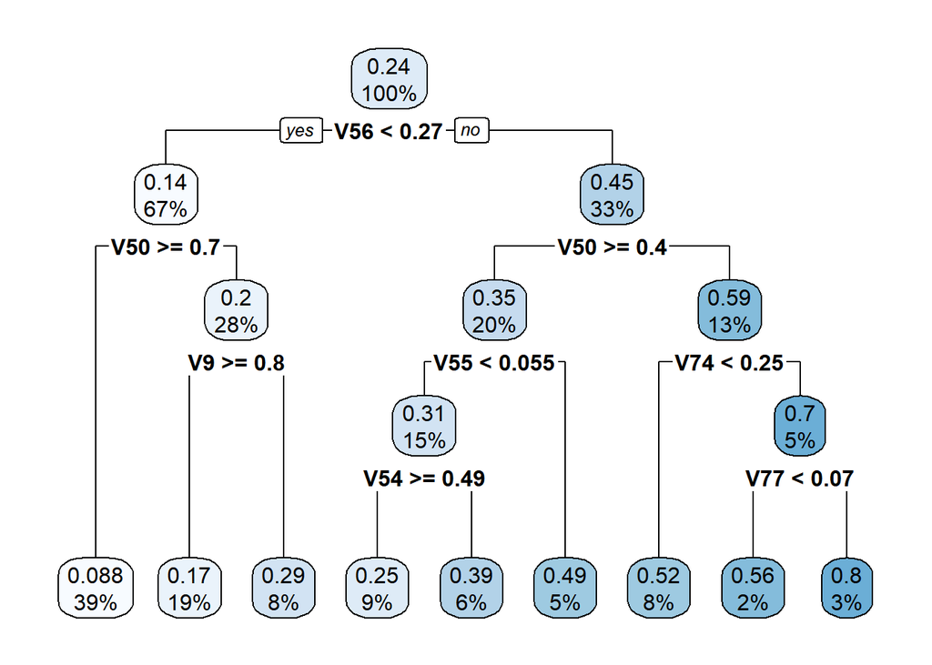

```r
rpart.plot(fit.opt.rpart)
```

```r
#These are the important variables chosen by model
fit.opt.rpart$variable.importance
```

```
##        V56        V50        V49        V55         V8         V9        V52
## 33.2173157 27.6213405 23.6279475 18.8574393 18.1800346 16.4986170  6.1776757
##        V51        V74        V16         V6        V47        V46        V33
##  5.7007232  2.5723939  2.0351952  1.9681285  1.8215440  1.7663457  1.7632323
##        V68        V69        V11        V77       V102       V104        V48
##  1.5307326  1.4896461  1.0471179  1.0060010  0.9792160  0.9792160  0.9481487
##        V54        V70        V71        V53       V126        V66        V57
##  0.9368225  0.8217289  0.7374490  0.7080635  0.6371340  0.5504521  0.5365339
##        V23        V72
##  0.4466247  0.4030515
```

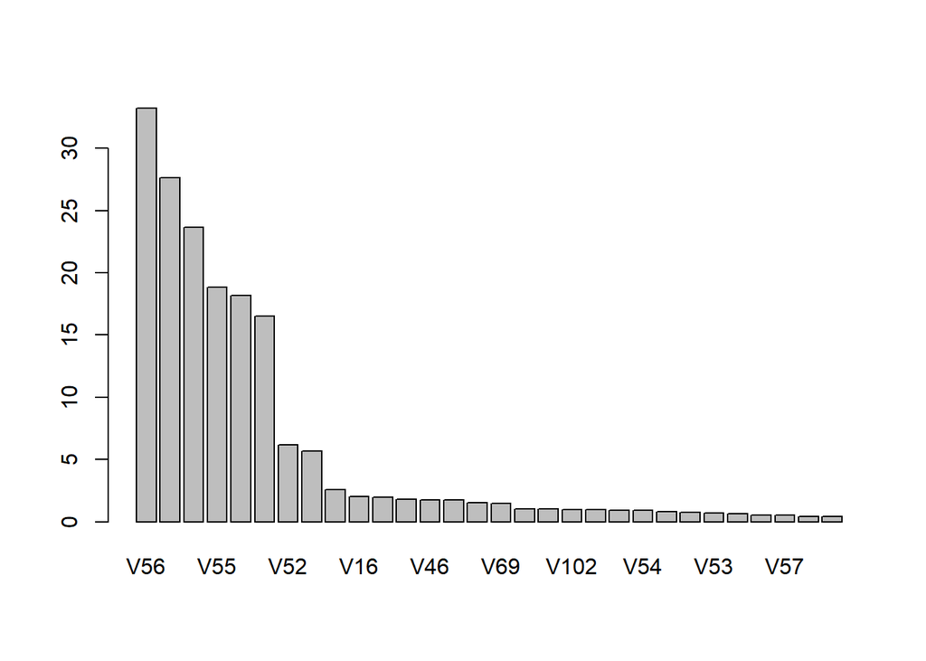

```r
barplot(fit.opt.rpart$variable.importance)
```

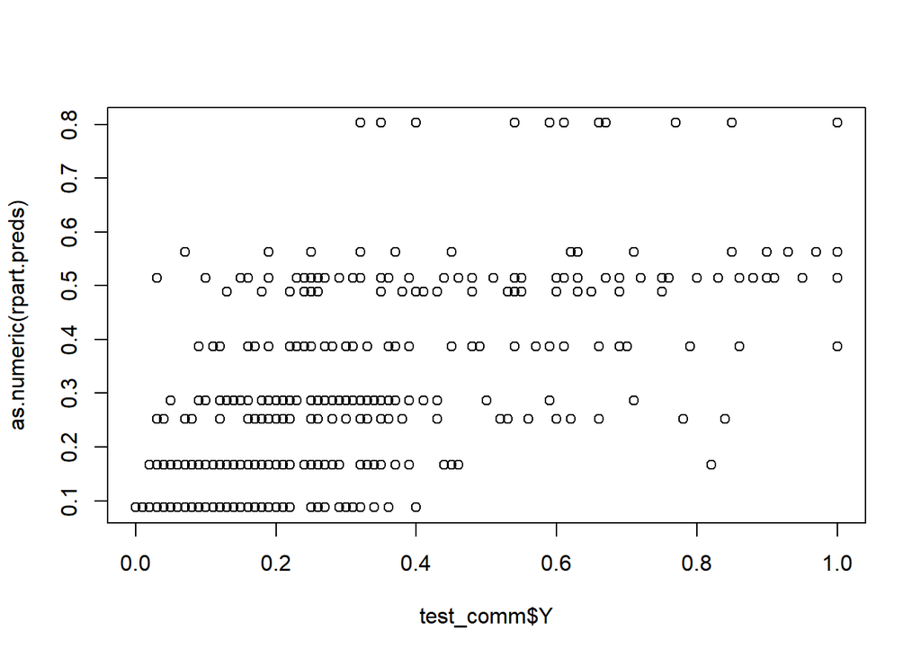

```r
rpart.preds=predict(fit.opt.rpart,test_comm)
plot(test_comm$Y,as.numeric(rpart.preds))
```

```r
rpart.perf<-RMSE(pred = rpart.preds,obs = test_comm$Y)
print(rpart.perf)
```

```
## [1] 0.1558405
```

3. Random Forest

```r
sqrt(ncol(Traindat)) #We choose values around this value for random forest
```

```
## [1] 11.04536
```

```r
Grid.Matrix= expand.grid(mtry=c(5,7,9,11,13,15))
control.param$allowParallel<-T
cl <- makeCluster(8)
registerDoSNOW(cl)

fit.rf <- caret::train(x = Traindat ,
                       y = TrainResponse,
                       method = "rf",
                       trControl = control.param,
                       tuneGrid = Grid.Matrix,
                       metric="RMSE",
                       ntree=500,
                       nodesize=5)
stopCluster(cl)

print(fit.rf)
```

```
## Random Forest
##
## 1395 samples
##  122 predictor
##
## No pre-processing
## Resampling: Cross-Validated (10 fold)
## Summary of sample sizes: 1257, 1254, 1257, 1255, 1255, 1256, ...
## Resampling results across tuning parameters:
##
##   mtry  RMSE       Rsquared   MAE
##    5    0.1382146  0.6430826  0.09665902
##    7    0.1376877  0.6442317  0.09611373
##    9    0.1376444  0.6434850  0.09598623
##   11    0.1373148  0.6446030  0.09565670
##   13    0.1372810  0.6449296  0.09555223
##   15    0.1374271  0.6436114  0.09553191
##
## RMSE was used to select the optimal model using the smallest value.
## The final value used for the model was mtry = 13.
```

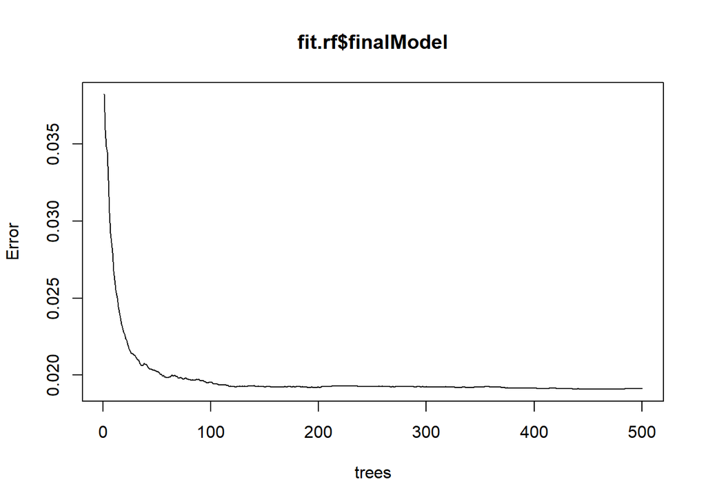

```r
plot(fit.rf$finalModel)
```

RMSE do not change so much for different m values

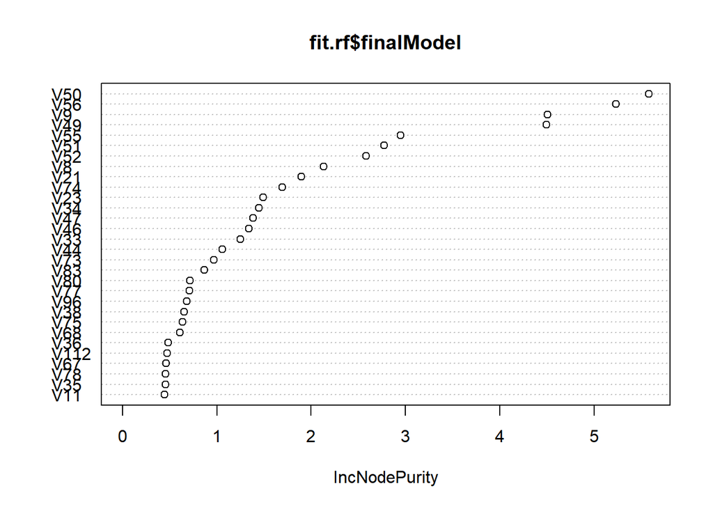

```r
varImpPlot(fit.rf$finalModel)
```

```r
imp<-data.frame(fit.rf$finalModel$importance,var = rownames(fit.rf$finalModel$importance))
imp %>% arrange(desc(IncNodePurity)) %>%
  mutate(csum_purity=cumsum(IncNodePurity)) %>%
  print()
```

```
##     IncNodePurity  var csum_purity
## 1      5.58236717  V50    5.582367
## 2      5.23466371  V56   10.817031
## 3      4.50729515   V9   15.324326
## 4      4.49815581  V49   19.822482
## 5      2.95045329  V55   22.772935
## 6      2.77169234  V51   25.544627
## 7      2.58208510  V52   28.126713
## 8      2.13125815   V8   30.257971
## 9      1.89905905  V21   32.157030
## 10     1.69537590  V74   33.852406
## 11     1.48892437  V23   35.341330
## 12     1.44700923  V34   36.788339
## 13     1.38667023  V47   38.175009
## 14     1.33779710  V46   39.512807
```

[output cut: 108 more lines]

12 variables cover 50% of gain

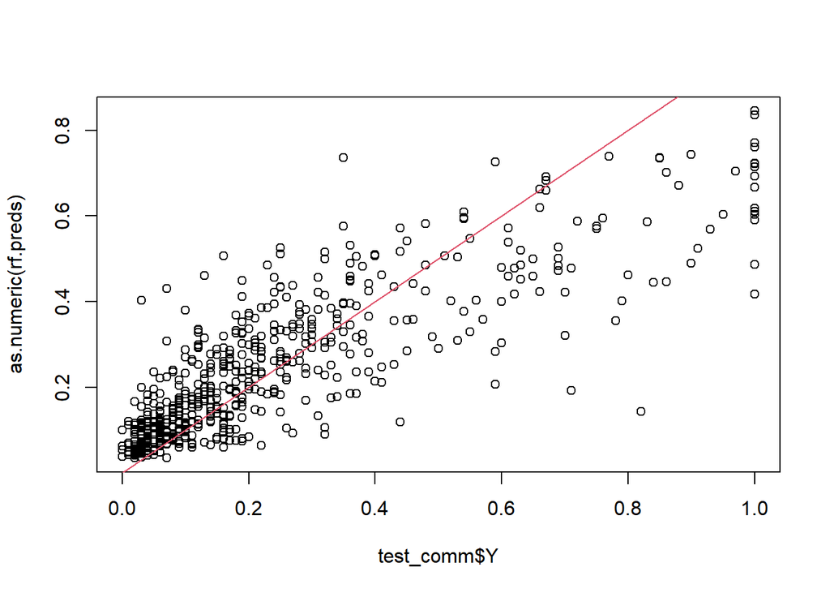

```r
rf.preds=predict(fit.rf,test_comm)
plot(test_comm$Y,as.numeric(rf.preds))
abline(a=0,b=1,col=2)
```

```r
rf.perf<-RMSE(pred = rf.preds,obs = test_comm$Y)
print(rf.perf)
```

```
## [1] 0.1325821
```

4. Stochastic Gradient Boosting

```r
Grid.Matrix= expand.grid(n.trees=seq(20,200,length.out = 6),
                         interaction.depth=c(3,5,7,9,12),
                         shrinkage=c(0.005,0.01,0.03,0.05,0.1),
                         n.minobsinnode=c(10))
cl <- makeCluster(8)
registerDoSNOW(cl)
fit.gbm <- caret::train(x = Traindat ,
                        y = TrainResponse,
                        method = "gbm",
                        trControl = control.param,
                        tuneGrid = Grid.Matrix,
                        metric="RMSE")
stopCluster(cl)
print(fit.gbm)
```

```
## Stochastic Gradient Boosting
##
## 1395 samples
##  122 predictor
##
## No pre-processing
## Resampling: Cross-Validated (10 fold)
## Summary of sample sizes: 1256, 1255, 1256, 1256, 1255, 1255, ...
## Resampling results across tuning parameters:
##
##   shrinkage  interaction.depth  n.trees  RMSE       Rsquared   MAE
##   0.005       3                  20      0.2185461  0.5535164  0.16846229
##   0.005       3                  56      0.2022064  0.5694432  0.15410929
##   0.005       3                  92      0.1894499  0.5782413  0.14320035
##   0.005       3                 128      0.1790990  0.5877754  0.13451261
##   0.005       3                 164      0.1709278  0.5947387  0.12754020
##   0.005       3                 200      0.1644847  0.6002457  0.12175893
##   0.005       5                  20      0.2176437  0.5872455  0.16776903
##   0.005       5                  56      0.2001799  0.5971700  0.15261358
##   0.005       5                  92      0.1863116  0.6031030  0.14071074
##   0.005       5                 128      0.1756322  0.6066155  0.13166004
##   0.005       5                 164      0.1671808  0.6112092  0.12446736
##   0.005       5                 200      0.1607173  0.6144004  0.11865933
##   0.005       7                  20      0.2172910  0.5925184  0.16741240
##   0.005       7                  56      0.1990020  0.6048186  0.15164122
##   0.005       7                  92      0.1849852  0.6085356  0.13960236
##   0.005       7                 128      0.1741220  0.6117532  0.13043445
##   0.005       7                 164      0.1655367  0.6166541  0.12306735
##   0.005       7                 200      0.1590417  0.6199480  0.11722073
##   0.005       9                  20      0.2169519  0.6037955  0.16719958
##   0.005       9                  56      0.1985935  0.6151718  0.15132778
##   0.005       9                  92      0.1843356  0.6153753  0.13907004
##   0.005       9                 128      0.1733214  0.6166684  0.12973389
##   0.005       9                 164      0.1649391  0.6197474  0.12236133
##   0.005       9                 200      0.1585392  0.6215184  0.11645142
##   0.005      12                  20      0.2167418  0.6084877  0.16697849
##   0.005      12                  56      0.1980457  0.6180951  0.15085304
##   0.005      12                  92      0.1832119  0.6248239  0.13807144
##   0.005      12                 128      0.1719015  0.6260561  0.12853198
##   0.005      12                 164      0.1632944  0.6280163  0.12096653
```

[output cut: 111 more lines]

```
##   0.100       9                  92      0.1414959  0.6221230  0.09505286
##   0.100       9                 128      0.1419421  0.6196697  0.09572995
##   0.100       9                 164      0.1428508  0.6148557  0.09649966
##   0.100       9                 200      0.1434738  0.6121504  0.09688332
##   0.100      12                  20      0.1444779  0.6116570  0.10103695
##   0.100      12                  56      0.1433362  0.6116689  0.09722854
##   0.100      12                  92      0.1457830  0.5998096  0.09845329
##   0.100      12                 128      0.1466970  0.5955976  0.09871420
##   0.100      12                 164      0.1471791  0.5936195  0.09951374
##   0.100      12                 200      0.1472770  0.5931613  0.09979166
##
## Tuning parameter 'n.minobsinnode' was held constant at a value of 10
## RMSE was used to select the optimal model using the smallest value.
## The final values used for the model were n.trees = 164, interaction.depth =
##  12, shrinkage = 0.03 and n.minobsinnode = 10.
```

```r
varImp(fit.gbm)
```

```
## gbm variable importance
##
##   only 20 most important variables shown (out of 122)
##
##     Overall
## V50 100.000
## V56  62.107
## V9   19.804
## V8    8.108
## V96   6.887
## V55   6.659
## V77   6.317
## V46   6.250
## V47   6.046
## V74   5.814
## V80   5.223
## V21   5.165
## V84   4.717
## V75   4.644
## V49   4.200
## V78   4.141
## V54   4.065
## V23   3.873
## V30   3.598
## V92   3.539
```

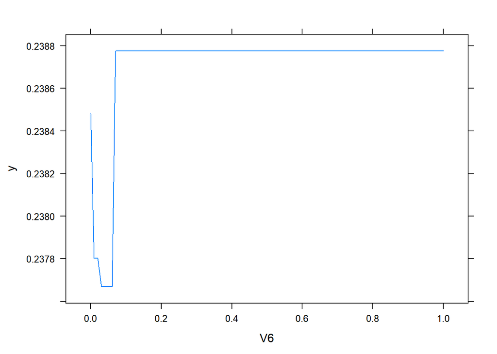

```r
plot(fit.gbm$finalModel)
```

While low number of trees may lead underfitting, high number of trees may lead overfit. We do not want to choose high shrinkage value because with high shrinkage low number of trees should be selected otherwise it will lead to overfit. Increasing depth also leads to overfit. Because of these reasons, we choose reasonable values with the hope of that they will not cause underfit or overfit. From the results it can be seen. With low shrinkage such as 0.005 we need higher interaction depth and higher ntrees. With high shrinkage such as 0.1 we need lower depth and trees otherwise rmse value is increasing.

```r
gbm.preds=predict(fit.gbm,test_comm)
gbm.perf<-RMSE(pred = gbm.preds,obs = test_comm$Y)
print(gbm.perf)
```

```
## [1] 0.1300312
```

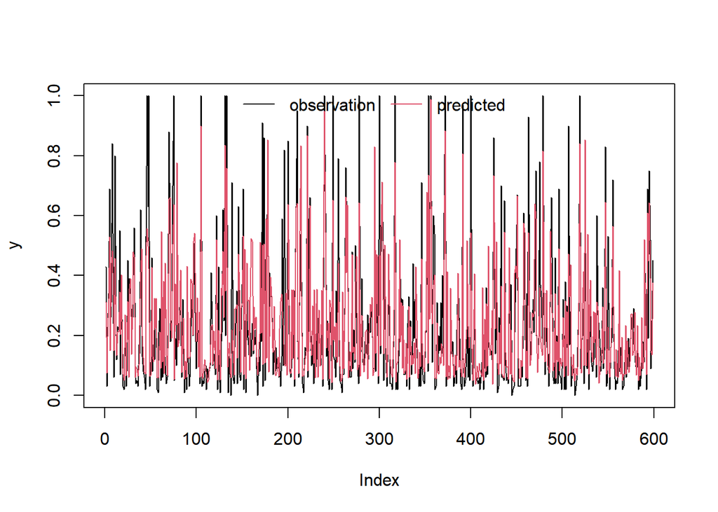

```r
plot(test_comm$Y,type="l",ylab="y")
lines(gbm.preds,col=2)
legend("top", legend=c("observation", "predicted"), col=1:2, lty=1, ncol=2, bty="n")
```

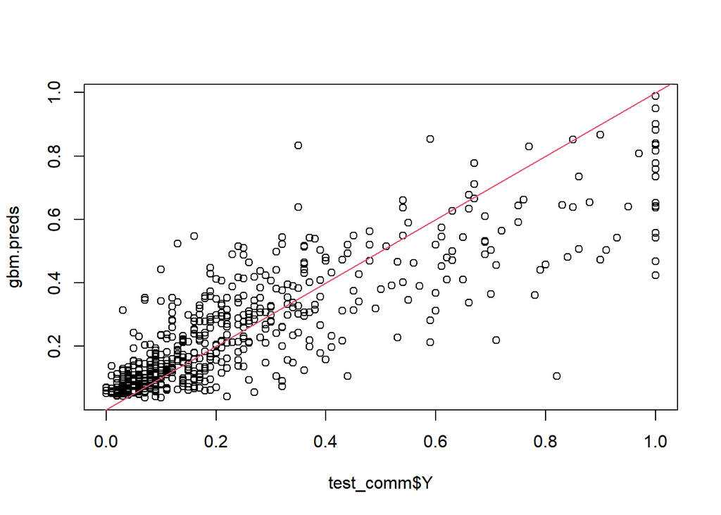

```r
plot(test_comm$Y,gbm.preds)
abline(a=0,b=1,col=2)
```

```r
comm_perfs<-cbind(c(glmnet.perf,rpart.perf,rf.perf,gbm.perf),
                  c(min(fit.glmnet$results$RMSE),fit.rpart$y["rmse.test.rmse"],min(fit.rf$results$RMSE),min(fit.gbm$results$RMSE)))


colnames(comm_perfs)<-c("Test","CV")
rownames(comm_perfs)<-c("glmnet","rpart","rf","gbm")
comm_perfs
```

```
##             Test        CV
## glmnet 0.1361839 0.1388133
## rpart  0.1558405 0.1647113
## rf     0.1325821 0.1372810
## gbm    0.1300312 0.1372211
```

1. SECOND PROBLEM: BALANCED CLASSIFICATION

The data is taken from here: http://archive.ics.uci.edu/ml/datasets/Spambase/ Source: Creators: Mark Hopkins, Erik Reeber, George Forman, Jaap Suermondt Hewlett-Packard Labs, 1501 Page Mill Rd., Palo Alto, CA 94304

Donor: George Forman (gforman at nospam hpl.hp.com) 650-857-7835

Data Set Information: The “spam” concept is diverse: advertisements for products/web sites, make money fast schemes, chain letters, pornography…

Our collection of spam e-mails came from our postmaster and individuals who had filed spam. Our collection of non-spam e-mails came from filed work and personal e-mails, and hence the word ‘george’ and the area code ‘650’ are indicators of non-spam. These are useful when constructing a personalized spam filter. One would either have to blind such non-spam indicators or get a very wide collection of non-spam to generate a general purpose spam filter. For background on spam:

Cranor, Lorrie F., LaMacchia, Brian A. Spam! Communications of the ACM, 41(8):74-83, 1998.

1. Hewlett-Packard Internal-only Technical Report. External forthcoming.
2. Determine whether a given email is spam or not.
3. ~7% misclassification error. False positives (marking good mail as spam) are very undesirable.If we insist on zero false positives in the training/testing set, 20-25% of the spam passed through the filter.

```r
spam_raw<-tibble(read.table("spambase.data",sep = ","))
dim(spam_raw)
```

```
## [1] 4601   58
```

```r
any(is.na(spam_raw))# no missing values
```

```
## [1] FALSE
```

```r
summary(spam_raw)
```

```
##        V1               V2               V3               V4
##  Min.   :0.0000   Min.   : 0.000   Min.   :0.0000   Min.   : 0.00000
##  1st Qu.:0.0000   1st Qu.: 0.000   1st Qu.:0.0000   1st Qu.: 0.00000
##  Median :0.0000   Median : 0.000   Median :0.0000   Median : 0.00000
##  Mean   :0.1046   Mean   : 0.213   Mean   :0.2807   Mean   : 0.06542
##  3rd Qu.:0.0000   3rd Qu.: 0.000   3rd Qu.:0.4200   3rd Qu.: 0.00000
##  Max.   :4.5400   Max.   :14.280   Max.   :5.1000   Max.   :42.81000
##        V5                V6               V7               V8
##  Min.   : 0.0000   Min.   :0.0000   Min.   :0.0000   Min.   : 0.0000
##  1st Qu.: 0.0000   1st Qu.:0.0000   1st Qu.:0.0000   1st Qu.: 0.0000
##  Median : 0.0000   Median :0.0000   Median :0.0000   Median : 0.0000
##  Mean   : 0.3122   Mean   :0.0959   Mean   :0.1142   Mean   : 0.1053
##  3rd Qu.: 0.3800   3rd Qu.:0.0000   3rd Qu.:0.0000   3rd Qu.: 0.0000
##  Max.   :10.0000   Max.   :5.8800   Max.   :7.2700   Max.   :11.1100
##        V9               V10               V11               V12
##  Min.   :0.00000   Min.   : 0.0000   Min.   :0.00000   Min.   :0.0000
##  1st Qu.:0.00000   1st Qu.: 0.0000   1st Qu.:0.00000   1st Qu.:0.0000
##  Median :0.00000   Median : 0.0000   Median :0.00000   Median :0.1000
##  Mean   :0.09007   Mean   : 0.2394   Mean   :0.05982   Mean   :0.5417
##  3rd Qu.:0.00000   3rd Qu.: 0.1600   3rd Qu.:0.00000   3rd Qu.:0.8000
##  Max.   :5.26000   Max.   :18.1800   Max.   :2.61000   Max.   :9.6700
##       V13               V14                V15              V16
##  Min.   :0.00000   Min.   : 0.00000   Min.   :0.0000   Min.   : 0.0000
##  1st Qu.:0.00000   1st Qu.: 0.00000   1st Qu.:0.0000   1st Qu.: 0.0000
##  Median :0.00000   Median : 0.00000   Median :0.0000   Median : 0.0000
##  Mean   :0.09393   Mean   : 0.05863   Mean   :0.0492   Mean   : 0.2488
##  3rd Qu.:0.00000   3rd Qu.: 0.00000   3rd Qu.:0.0000   3rd Qu.: 0.1000
##  Max.   :5.55000   Max.   :10.00000   Max.   :4.4100   Max.   :20.0000
##       V17              V18              V19              V20
##  Min.   :0.0000   Min.   :0.0000   Min.   : 0.000   Min.   : 0.00000
##  1st Qu.:0.0000   1st Qu.:0.0000   1st Qu.: 0.000   1st Qu.: 0.00000
##  Median :0.0000   Median :0.0000   Median : 1.310   Median : 0.00000
##  Mean   :0.1426   Mean   :0.1847   Mean   : 1.662   Mean   : 0.08558
##  3rd Qu.:0.0000   3rd Qu.:0.0000   3rd Qu.: 2.640   3rd Qu.: 0.00000
##  Max.   :7.1400   Max.   :9.0900   Max.   :18.750   Max.   :18.18000
##       V21               V22               V23              V24
##  Min.   : 0.0000   Min.   : 0.0000   Min.   :0.0000   Min.   : 0.00000
##  1st Qu.: 0.0000   1st Qu.: 0.0000   1st Qu.:0.0000   1st Qu.: 0.00000
##  Median : 0.2200   Median : 0.0000   Median :0.0000   Median : 0.00000
##  Mean   : 0.8098   Mean   : 0.1212   Mean   :0.1016   Mean   : 0.09427
```

[output cut: 50 more lines]

```
##  Max.   :4.38500   Max.   :9.752   Max.   :4.08100   Max.   :32.4780
##       V53               V54                V55                V56
##  Min.   :0.00000   Min.   : 0.00000   Min.   :   1.000   Min.   :   1.00
##  1st Qu.:0.00000   1st Qu.: 0.00000   1st Qu.:   1.588   1st Qu.:   6.00
##  Median :0.00000   Median : 0.00000   Median :   2.276   Median :  15.00
##  Mean   :0.07581   Mean   : 0.04424   Mean   :   5.191   Mean   :  52.17
##  3rd Qu.:0.05200   3rd Qu.: 0.00000   3rd Qu.:   3.706   3rd Qu.:  43.00
##  Max.   :6.00300   Max.   :19.82900   Max.   :1102.500   Max.   :9989.00
##       V57               V58
##  Min.   :    1.0   Min.   :0.000
##  1st Qu.:   35.0   1st Qu.:0.000
##  Median :   95.0   Median :0.000
##  Mean   :  283.3   Mean   :0.394
##  3rd Qu.:  266.0   3rd Qu.:1.000
##  Max.   :15841.0   Max.   :1.000
```

```r
str(spam_raw)
```

```
## tibble [4,601 x 58] (S3: tbl_df/tbl/data.frame)
##  $ V1 : num [1:4601] 0 0.21 0.06 0 0 0 0 0 0.15 0.06 ...
##  $ V2 : num [1:4601] 0.64 0.28 0 0 0 0 0 0 0 0.12 ...
##  $ V3 : num [1:4601] 0.64 0.5 0.71 0 0 0 0 0 0.46 0.77 ...
##  $ V4 : num [1:4601] 0 0 0 0 0 0 0 0 0 0 ...
##  $ V5 : num [1:4601] 0.32 0.14 1.23 0.63 0.63 1.85 1.92 1.88 0.61 0.19 ...
##  $ V6 : num [1:4601] 0 0.28 0.19 0 0 0 0 0 0 0.32 ...
##  $ V7 : num [1:4601] 0 0.21 0.19 0.31 0.31 0 0 0 0.3 0.38 ...
##  $ V8 : num [1:4601] 0 0.07 0.12 0.63 0.63 1.85 0 1.88 0 0 ...
##  $ V9 : num [1:4601] 0 0 0.64 0.31 0.31 0 0 0 0.92 0.06 ...
##  $ V10: num [1:4601] 0 0.94 0.25 0.63 0.63 0 0.64 0 0.76 0 ...
##  $ V11: num [1:4601] 0 0.21 0.38 0.31 0.31 0 0.96 0 0.76 0 ...
##  $ V12: num [1:4601] 0.64 0.79 0.45 0.31 0.31 0 1.28 0 0.92 0.64 ...
##  $ V13: num [1:4601] 0 0.65 0.12 0.31 0.31 0 0 0 0 0.25 ...
##  $ V14: num [1:4601] 0 0.21 0 0 0 0 0 0 0 0 ...
```

[output cut: 44 more lines]

Performance metric is accuracy we do not want false positives meaning that we do not want to mark good e-mails as spam and we also do not want to pass spam e-mails. Therefore, We need to classify correctly.

```r
spam<-spam_raw %>%
  rename(Y=V58) %>%
  mutate(Y=ifelse(Y==1,"spam",
                  ifelse(Y==0,"non_spam",NA)))
table(spam$Y)
```

```
##
## non_spam     spam
##     2788     1813
```

```r
# 30% of data is selected for test
set.seed(123)
TrainIndex <- sample(1:nrow(spam),size = trunc(nrow(spam)*0.7),replace = F)

train_spam<- spam[TrainIndex,] %>% as.data.frame()
test_spam <- spam[-TrainIndex,] %>% as.data.frame()

Traindat<-train_spam %>% select(-Y)
TrainResponse<-train_spam$Y

control.param<-trainControl(method = "cv",
                            number = 10,
                            allowParallel = F,
                            returnResamp = "all",
                            savePredictions = "all",
                            classProbs = T)
```

1. Glmnet Method

```r
Grid.Matrix= expand.grid(alpha=1,
                         lambda=c(0.0001,0.001,0.005,0.01,0.05,0.1))


set.seed(123)
fit.glmnet <- caret::train(x = Traindat ,
                           y = TrainResponse,
                           method = "glmnet",
                           trControl = control.param,
                           tuneGrid = Grid.Matrix,
                           metric="Accuracy")
print(fit.glmnet)
```

```
## glmnet
##
## 3220 samples
##   57 predictor
##    2 classes: 'non_spam', 'spam'
##
## No pre-processing
## Resampling: Cross-Validated (10 fold)
## Summary of sample sizes: 2898, 2898, 2897, 2898, 2898, 2899, ...
## Resampling results across tuning parameters:
##
##   lambda  Accuracy   Kappa
##   1e-04   0.9285673  0.8493373
##   1e-03   0.9273289  0.8463749
##   5e-03   0.9176919  0.8250607
##   1e-02   0.9089991  0.8051464
##   5e-02   0.8403702  0.6459367
##   1e-01   0.7484521  0.4157925
##
## Tuning parameter 'alpha' was held constant at a value of 1
## Accuracy was used to select the optimal model using the largest value.
## The final values used for the model were alpha = 1 and lambda = 1e-04.
```

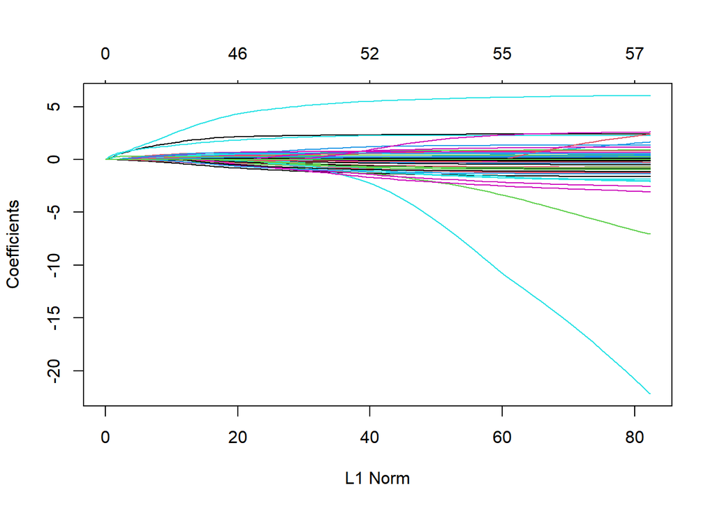

```r
plot(fit.glmnet$finalModel)
```

```r
glmnet.preds.prob=predict(fit.glmnet,test_spam,type="prob")[,"spam"]
#If we do not want false positives we can increase threshold
#If we do not want false negatives we can decrease threshold
for(thr in seq(0.2,0.8,by=0.2)){
  glmnet.preds<-ifelse(glmnet.preds.prob>thr,"spam","non_spam")
  conf.mat<-confusionMatrix(table(glmnet.preds,test_spam$Y))
  print(thr)
  print(conf.mat)
}
```

```
## [1] 0.2
## Confusion Matrix and Statistics
##
##
## glmnet.preds non_spam spam
##     non_spam      700   14
##     spam          130  537
##
##                Accuracy : 0.8957
##                  95% CI : (0.8784, 0.9114)
##     No Information Rate : 0.601
##     P-Value [Acc > NIR] : < 2.2e-16
##
##                   Kappa : 0.79
##
##  Mcnemar's Test P-Value : < 2.2e-16
##
##             Sensitivity : 0.8434
##             Specificity : 0.9746
##          Pos Pred Value : 0.9804
##          Neg Pred Value : 0.8051
##              Prevalence : 0.6010
##          Detection Rate : 0.5069
##    Detection Prevalence : 0.5170
##       Balanced Accuracy : 0.9090
##
##        'Positive' Class : non_spam
##
## [1] 0.4
## Confusion Matrix and Statistics
##
##
## glmnet.preds non_spam spam
##     non_spam      768   39
##     spam           62  512
##
##                Accuracy : 0.9269
##                  95% CI : (0.9118, 0.94)
##     No Information Rate : 0.601
##     P-Value [Acc > NIR] : < 2e-16
```

[output cut: 57 more lines]

```
##                   Kappa : 0.7599
##
##  Mcnemar's Test P-Value : < 2.2e-16
##
##             Sensitivity : 0.9699
##             Specificity : 0.7659
##          Pos Pred Value : 0.8619
##          Neg Pred Value : 0.9441
##              Prevalence : 0.6010
##          Detection Rate : 0.5829
##    Detection Prevalence : 0.6763
##       Balanced Accuracy : 0.8679
##
##        'Positive' Class : non_spam
##
```

```r
# We choose 0.5 as threshold to compare it with cv result
glmnet.preds<-ifelse(glmnet.preds.prob>0.5,"spam","non_spam")
conf.mat<-confusionMatrix(table(glmnet.preds,test_spam$Y))
print(conf.mat)
```

```
## Confusion Matrix and Statistics
##
##
## glmnet.preds non_spam spam
##     non_spam      789   58
##     spam           41  493
##
##                Accuracy : 0.9283
##                  95% CI : (0.9134, 0.9414)
##     No Information Rate : 0.601
##     P-Value [Acc > NIR] : <2e-16
##
##                   Kappa : 0.8497
##
##  Mcnemar's Test P-Value : 0.1078
##
##             Sensitivity : 0.9506
##             Specificity : 0.8947
##          Pos Pred Value : 0.9315
##          Neg Pred Value : 0.9232
##              Prevalence : 0.6010
##          Detection Rate : 0.5713
##    Detection Prevalence : 0.6133
##       Balanced Accuracy : 0.9227
##
##        'Positive' Class : non_spam
##
```

```r
glmnet.perf<-conf.mat$overall["Accuracy"]
print(glmnet.perf)
```

```
##  Accuracy
## 0.9283128
```

For start 92% accuracy is good. In the paper it is stated that there is 7% misclassification error.

2. Rpart Method

```r
class.task = makeClassifTask(id = "spam", data = train_spam, target = "Y")
resamp = makeResampleDesc("CV", iters = 10)
lrn = makeLearner("classif.rpart")
control.grid = makeTuneControlGrid()
ps = makeParamSet(
  makeDiscreteParam("cp", values = c(0.001,0.005,0.01,0.02,0.05,0.1)),
  makeDiscreteParam("minsplit", values = seq(1,11,length.out = 6))
)

set.seed(123)
fit.rpart = tuneParams(lrn, task = class.task, resampling = resamp, control = control.grid, par.set = ps, measures = list(acc,timetrain))
```

```
## [Tune] Started tuning learner classif.rpart for parameter set:
```

```
##              Type len Def                         Constr Req Tunable Trafo
## cp       discrete   -   - 0.001,0.005,0.01,0.02,0.05,0.1   -    TRUE     -
## minsplit discrete   -   -                   1,3,5,7,9,11   -    TRUE     -
```

```
## With control class: TuneControlGrid
```

```
## Imputation value: -0Imputation value: Inf
```

```
## [Tune-x] 1: cp=0.001; minsplit=1
```

```
## [Tune-y] 1: acc.test.mean=0.9124224,timetrain.test.mean=0.0640000; time: 0.0 min
```

```
## [Tune-x] 2: cp=0.005; minsplit=1
```

```
## [Tune-y] 2: acc.test.mean=0.9040373,timetrain.test.mean=0.0500000; time: 0.0 min
```

```
## [Tune-x] 3: cp=0.01; minsplit=1
```

```
## [Tune-y] 3: acc.test.mean=0.8885093,timetrain.test.mean=0.0470000; time: 0.0 min
```

```
## [Tune-x] 4: cp=0.02; minsplit=1
```

```
## [Tune-y] 4: acc.test.mean=0.8888199,timetrain.test.mean=0.0380000; time: 0.0 min
```

```
## [Tune-x] 5: cp=0.05; minsplit=1
```

```
## [Tune-y] 5: acc.test.mean=0.8618012,timetrain.test.mean=0.0330000; time: 0.0 min
```

```
## [Tune-x] 6: cp=0.1; minsplit=1
```

```
## [Tune-y] 6: acc.test.mean=0.8403727,timetrain.test.mean=0.0320000; time: 0.0 min
```

```
## [Tune-x] 7: cp=0.001; minsplit=3
```

```
## [Tune-y] 7: acc.test.mean=0.9124224,timetrain.test.mean=0.0650000; time: 0.0 min
```

```
## [Tune-x] 8: cp=0.005; minsplit=3
```

```
## [Tune-y] 8: acc.test.mean=0.9040373,timetrain.test.mean=0.0460000; time: 0.0 min
```

```
## [Tune-x] 9: cp=0.01; minsplit=3
```

```
## [Tune-y] 9: acc.test.mean=0.8885093,timetrain.test.mean=0.0400000; time: 0.0 min
```

```
## [Tune-x] 10: cp=0.02; minsplit=3
```

```
## [Tune-y] 10: acc.test.mean=0.8888199,timetrain.test.mean=0.0320000; time: 0.0 min
```

```
## [Tune-x] 11: cp=0.05; minsplit=3
```

```
## [Tune-y] 11: acc.test.mean=0.8618012,timetrain.test.mean=0.0310000; time: 0.0 min
```

```
## [Tune-x] 12: cp=0.1; minsplit=3
```

```
## [Tune-y] 12: acc.test.mean=0.8403727,timetrain.test.mean=0.0300000; time: 0.0 min
```

```
## [Tune-x] 13: cp=0.001; minsplit=5
```

```
## [Tune-y] 13: acc.test.mean=0.9118012,timetrain.test.mean=0.0610000; time: 0.0 min
```

```
## [Tune-x] 14: cp=0.005; minsplit=5
```

```
## [Tune-y] 14: acc.test.mean=0.9040373,timetrain.test.mean=0.0500000; time: 0.0 min
```

```
## [Tune-x] 15: cp=0.01; minsplit=5
```

```
## [Tune-y] 15: acc.test.mean=0.8885093,timetrain.test.mean=0.0440000; time: 0.0 min
```

```
## [Tune-x] 16: cp=0.02; minsplit=5
```

```
## [Tune-y] 16: acc.test.mean=0.8888199,timetrain.test.mean=0.0390000; time: 0.0 min
```

```
## [Tune-x] 17: cp=0.05; minsplit=5
```

```
## [Tune-y] 17: acc.test.mean=0.8618012,timetrain.test.mean=0.0310000; time: 0.0 min
```

```
## [Tune-x] 18: cp=0.1; minsplit=5
```

```
## [Tune-y] 18: acc.test.mean=0.8403727,timetrain.test.mean=0.0260000; time: 0.0 min
```

```
## [Tune-x] 19: cp=0.001; minsplit=7
```

```
## [Tune-y] 19: acc.test.mean=0.9121118,timetrain.test.mean=0.0670000; time: 0.0 min
```

```
## [Tune-x] 20: cp=0.005; minsplit=7
```

```
## [Tune-y] 20: acc.test.mean=0.9040373,timetrain.test.mean=0.0570000; time: 0.0 min
```

```
## [Tune-x] 21: cp=0.01; minsplit=7
```

```
## [Tune-y] 21: acc.test.mean=0.8885093,timetrain.test.mean=0.0470000; time: 0.0 min
```

```
## [Tune-x] 22: cp=0.02; minsplit=7
```

```
## [Tune-y] 22: acc.test.mean=0.8888199,timetrain.test.mean=0.0350000; time: 0.0 min
```

```
## [Tune-x] 23: cp=0.05; minsplit=7
```

```
## [Tune-y] 23: acc.test.mean=0.8618012,timetrain.test.mean=0.0310000; time: 0.0 min
```

```
## [Tune-x] 24: cp=0.1; minsplit=7
```

```
## [Tune-y] 24: acc.test.mean=0.8403727,timetrain.test.mean=0.0240000; time: 0.0 min
```

```
## [Tune-x] 25: cp=0.001; minsplit=9
```

```
## [Tune-y] 25: acc.test.mean=0.9102484,timetrain.test.mean=0.0660000; time: 0.0 min
```

```
## [Tune-x] 26: cp=0.005; minsplit=9
```

```
## [Tune-y] 26: acc.test.mean=0.9040373,timetrain.test.mean=0.0580000; time: 0.0 min
```

```
## [Tune-x] 27: cp=0.01; minsplit=9
```

```
## [Tune-y] 27: acc.test.mean=0.8885093,timetrain.test.mean=0.0450000; time: 0.0 min
```

```
## [Tune-x] 28: cp=0.02; minsplit=9
```

```
## [Tune-y] 28: acc.test.mean=0.8888199,timetrain.test.mean=0.0350000; time: 0.0 min
```

```
## [Tune-x] 29: cp=0.05; minsplit=9
```

```
## [Tune-y] 29: acc.test.mean=0.8618012,timetrain.test.mean=0.0320000; time: 0.0 min
```

```
## [Tune-x] 30: cp=0.1; minsplit=9
```

```
## [Tune-y] 30: acc.test.mean=0.8403727,timetrain.test.mean=0.0260000; time: 0.0 min
```

```
## [Tune-x] 31: cp=0.001; minsplit=11
```

```
## [Tune-y] 31: acc.test.mean=0.9108696,timetrain.test.mean=0.0910000; time: 0.0 min
```

```
## [Tune-x] 32: cp=0.005; minsplit=11
```

```
## [Tune-y] 32: acc.test.mean=0.9040373,timetrain.test.mean=0.0550000; time: 0.0 min
```

```
## [Tune-x] 33: cp=0.01; minsplit=11
```

```
## [Tune-y] 33: acc.test.mean=0.8885093,timetrain.test.mean=0.0470000; time: 0.0 min
```

```
## [Tune-x] 34: cp=0.02; minsplit=11
```

```
## [Tune-y] 34: acc.test.mean=0.8888199,timetrain.test.mean=0.0450000; time: 0.0 min
```

```
## [Tune-x] 35: cp=0.05; minsplit=11
```

```
## [Tune-y] 35: acc.test.mean=0.8618012,timetrain.test.mean=0.0370000; time: 0.0 min
```

```
## [Tune-x] 36: cp=0.1; minsplit=11
```

```
## [Tune-y] 36: acc.test.mean=0.8403727,timetrain.test.mean=0.0310000; time: 0.0 min
```

```
## [Tune] Result: cp=0.001; minsplit=3 : acc.test.mean=0.9124224,timetrain.test.mean=0.0650000
```

```r
opt.grid = as.data.frame(fit.rpart$opt.path)
print(opt.grid)
```

```
##       cp minsplit acc.test.mean timetrain.test.mean dob eol error.message
## 1  0.001        1     0.9124224               0.064   1  NA          <NA>
## 2  0.005        1     0.9040373               0.050   2  NA          <NA>
## 3   0.01        1     0.8885093               0.047   3  NA          <NA>
## 4   0.02        1     0.8888199               0.038   4  NA          <NA>
## 5   0.05        1     0.8618012               0.033   5  NA          <NA>
## 6    0.1        1     0.8403727               0.032   6  NA          <NA>
## 7  0.001        3     0.9124224               0.065   7  NA          <NA>
## 8  0.005        3     0.9040373               0.046   8  NA          <NA>
## 9   0.01        3     0.8885093               0.040   9  NA          <NA>
## 10  0.02        3     0.8888199               0.032  10  NA          <NA>
## 11  0.05        3     0.8618012               0.031  11  NA          <NA>
## 12   0.1        3     0.8403727               0.030  12  NA          <NA>
## 13 0.001        5     0.9118012               0.061  13  NA          <NA>
## 14 0.005        5     0.9040373               0.050  14  NA          <NA>
```

[output cut: 59 more lines]

```r
opt.grid %>% group_by(cp) %>%
  summarise(mean(acc.test.mean),.groups="keep") %>%
  print()
```

```
## # A tibble: 6 x 2
## # Groups:   cp [6]
##   cp    `mean(acc.test.mean)`
##   <fct>                 <dbl>
## 1 0.001                 0.912
## 2 0.005                 0.904
## 3 0.01                  0.889
## 4 0.02                  0.889
## 5 0.05                  0.862
## 6 0.1                   0.840
```